# Part II - Ford GoBike System Data Analysis Explained

## by Sandra Barasa

## Investigation Overview

This project is centred on information about individual rides made in a bike-sharing system covering the greater San Francisco Bay area.

In my analysis, I investigated features that had an impact on the cycling duration of members, focusing mainly on user type, members' age, members' gender, start day and bike-share-for-all-trip.

## Dataset Overview

The data set included approximately 183,000 members, with data showing:

- Duration of the trip in seconds.
- Start and end time of the trips.
- Start and end-station names, IDs, latitudes and longitudes.
- Bike IDs.
- User Type ie Subscriber or Customer.
- Members' birth year and gender.
- Whether the bike was used for the whole trip or not.

After the preliminary wrangling, about 8400 data points were excluded in the analysis due to missing data.

## Distribution of Gender

There are generally more males than females and 'other' genders, with males accounting for about 74.5% of the data.

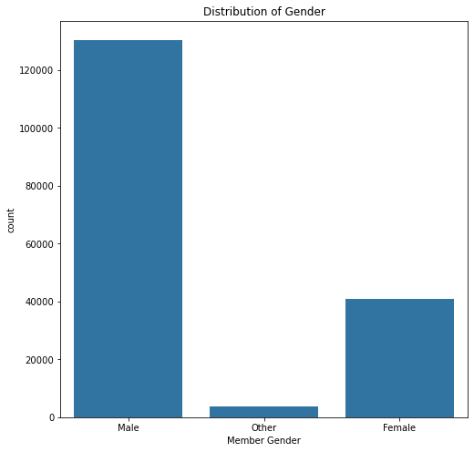

## Relationship Between Duration of Trips and Gender Plotted Against Start Day of the Week

'Other' gender-category rode the bikes for longer durations than females and males, despite being the minority. The opposite is true for the males. i.e. Despite showing significantly high numbers, they on average rode for the shortest duration of time.

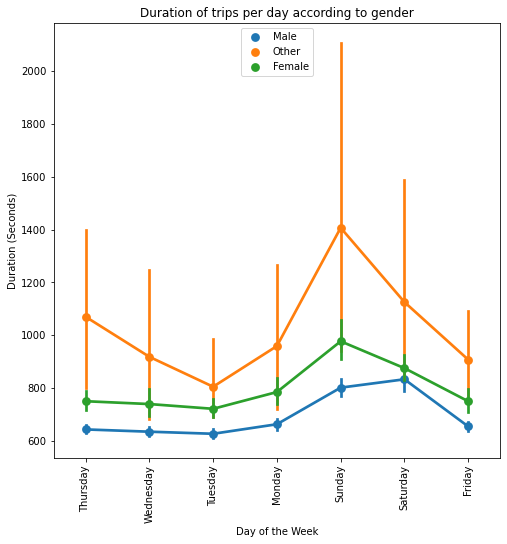

## Distribution of User Type

There are more subscribers than there are customers, with subscribers accounting for 90.5% of the data.

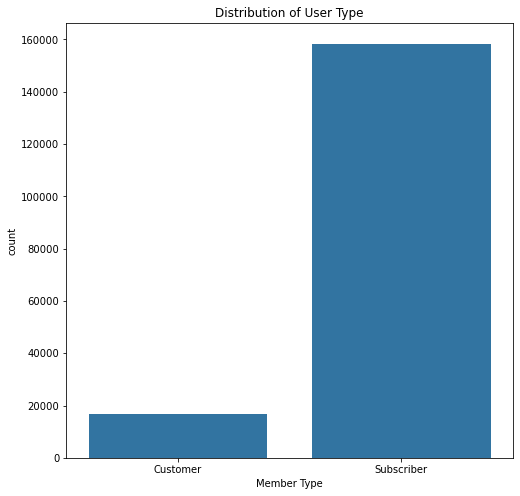

## Relationship Between Duration of Trips and User Type Plotted Against Start Day of the Week

Despite subscribers being more than customers in our data, the plot shows that customers actually ride for longer periods of time than the subscribers.

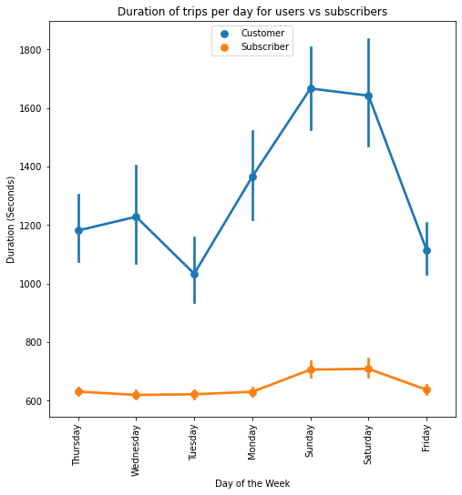

## Relationship Between Duration of Trips and Age Group Plotted Against Gender

The age groups with the most active bike riders are as below:

- Male: 41 - 50 years
- Female: 51 - 60 years
- Other: 31 - 40 years

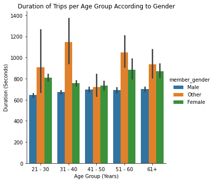